# NLP Model Development - Milestone Report

Faustin GASHAKAMBA

2/3/2021

## Overview of the milestone report

The purpose of this report is explain the exploratory analysis steps that were taken to look into the data that will be used to build, train, and test a text prediction app that will developed as part of this capstone project. These steps include the loading of the data, generating summaries on it using graphs and tables, and generating an N-grams model that will be used in the final NLP model. Finally, the strategies that will be used in the final algorithm will be outlined and a plan will be presented on how the algorithm will be developed and deployed.

## Loading the data (Blogs, News, Twitter)

```r
blogs <- readLines("en_US.blogs.txt", warn = FALSE, encoding = "UTF-8")
news <- readLines("en_US.news.txt", warn = FALSE, encoding = "UTF-8")
twitter <- readLines("en_US.twitter.txt", warn = FALSE, encoding = "UTF-8")
```

## Generating Data Summaries

1. Number of lines, words, and characters in each file

```r
library(stringi) # stats files
# Number of Lines num.lines
len_blogs <- length(blogs)
len_news <- length(news)
len_twitter <- length(twitter)
# Number of characters
nchar_blogs <- sum(nchar(blogs))
nchar_news <- sum(nchar(news))
nchar_twitter <- sum(nchar(twitter))
# Counting the Words (num.words)
nword_blogs <- sum(stri_count_words(blogs))
nword_news <- sum(stri_count_words(news))
nword_twitter <-sum(stri_count_words(twitter))
# create table
corpus <- data.frame(file.name = c("blogs", "news", "twitter"),
num.lines = c(formatC(len_blogs,big.mark=","), formatC(len_news,big.mark=","), formatC(len_twitter,big.mark=",")),
num.character = c(formatC(nchar_blogs, big.mark=","), formatC(nchar_news, big.mark=","), formatC(nchar_twitter,big.mark=",")),
num.words = c(formatC(nword_blogs, big.mark=","), formatC(nword_news, big.mark=","), formatC(nword_twitter, big.mark=",")))
head(corpus)
```

```
##   file.name num.lines num.character  num.words
## 1     blogs   899,288   206,824,505 37,546,239
## 2      news    77,259    15,639,408  2,674,536
## 3   twitter 2,360,148   162,096,031 30,093,372
```

```r
# library(stringr)
# library(ggplot2)
# library(gridExtra)
# line_word_count_blogs <- sapply(blogs, str_count)
# line_word_count_twitter <- sapply(twitter, str_count)
# line_word_count_news <- sapply(news, str_count)
#
# blogs_plot <- qplot(line_word_count_blogs,
#                    geom = "histogram",
#                    main = "US Blogs",
#                    xlab = "Words per Line",
#                    ylab = "Count",
#                    binwidth = 5)
# twitter_plot <- qplot(line_word_count_twitter,
#                    geom = "histogram",
#                    main = "US Blogs",
#                    xlab = "Words per Line",
#                    ylab = "Count",
#                    binwidth = 5)
# news_plot <- qplot(line_word_count_news,
#                    geom = "histogram",
#                    main = "US Blogs",
#                    xlab = "Words per Line",
#                    ylab = "Count",
#                    binwidth = 5)
# grid.arrange(blogs_plot, twitter_plot, news_plot,ncol=3)
```

## Sampling and Cleaning the Data

Here, we will remove all non-English characters and then compile a sample dataset that is composed of 1% of each of the 3 original datasets.

```r
set.seed(65432)
blogs_1 <-iconv(blogs,"latin1","ASCII",sub="")
news_1 <-iconv(news,"latin1","ASCII",sub="")
twitter_1 <-iconv(twitter,"latin1","ASCII",sub="")
# sample data set only 1% of each file
sample_data <-c(sample(blogs_1,length(blogs_1)*0.01),
               sample(news_1,length(news_1)*0.01),
               sample(twitter_1,length(twitter_1)*0.01))
```

## Cleaning and Building the Corpus

```r
library(tm) # Text mining package
library(NLP) # Language processing package
corpus <- VCorpus(VectorSource(sample_data))
corpus1 <- tm_map(corpus,removePunctuation)
corpus2 <- tm_map(corpus1,stripWhitespace)

corpus3 <- tm_map(corpus2,tolower) # Convert to lowercase
corpus4 <- tm_map(corpus3,removeNumbers)
corpus5 <- tm_map(corpus4,PlainTextDocument)

#removing stop words in English (a, as, at, so, etc.)
corpus6 <- tm_map(corpus5,removeWords,stopwords("english"))
```

## Building N-Grams model

An n-gram model is a contiguous sequence of n items from a given sequence of text or speech. Unigrams are single words. Bigrams are two words combinations. Trigrams are three-word combinations.

The following function is used to extract 1-grams, 2-grams, and 3-grams from the text Corpus using RWeka package.

```r
library(RWeka) # tokenizer - create unigrams, bigrams, trigrams
# We RWeka package to construct functions that tokenize the sample and construct matrices of uniqrams, bigrams, and trigrams.
one<-function(x) NGramTokenizer(x,Weka_control(min=1,max=1))
two<-function(x) NGramTokenizer(x,Weka_control(min=2,max=2))
thr<-function(x) NGramTokenizer(x,Weka_control(min=3,max=3))
one_table<-TermDocumentMatrix(corpus6,control=list(tokenize=one))
two_table<-TermDocumentMatrix(corpus6,control=list(tokenize=two))
thr_table<-TermDocumentMatrix(corpus6,control=list(tokenize=thr))
# Save the n-grams into .rds files
saveRDS(one_table, file = "ng1.rds", ascii = FALSE, version = NULL, compress = TRUE, refhook = NULL)
saveRDS(two_table, file = "ng2.rds", ascii = FALSE, version = NULL, compress = TRUE, refhook = NULL)
saveRDS(thr_table, file = "ng3.rds", ascii = FALSE, version = NULL, compress = TRUE, refhook = NULL)
#Then we find the frequency of terms in each of these 3 matrices and construct dataframes of these frequencies.
one_corpus<-findFreqTerms(one_table,lowfreq=1000)
two_corpus<-findFreqTerms(two_table,lowfreq=80)
thr_corpus<-findFreqTerms(thr_table,lowfreq=10)
one_corpus_num<-rowSums(as.matrix(one_table[one_corpus,]))
# One_corpus
one_corpus_table<-data.frame(Word=names(one_corpus_num),frequency=one_corpus_num)
one_corpus_sort<-one_corpus_table[order(-one_corpus_table$frequency),]
head(one_corpus_sort)
```

```
##      Word frequency
## just just      2462
## like like      2253
## will will      2139
## one   one      2116
## get   get      1904
## can   can      1884
```

```r
# Two_corpus
two_corpus_num<-rowSums(as.matrix(two_table[two_corpus,]))
two_corpus_table<-data.frame(Word=names(two_corpus_num),frequency=two_corpus_num)
two_corpus_sort<-two_corpus_table[order(-two_corpus_table$frequency),]
head(two_corpus_sort)
```

```
##                  Word frequency
## right now   right now       235
## cant wait   cant wait       201
## dont know   dont know       162
## last night last night       143
## im going     im going       122
## feel like   feel like       111
```

```r
# Three_corpus
thr_corpus_num<-rowSums(as.matrix(thr_table[thr_corpus,]))
thr_corpus_table<-data.frame(Word=names(thr_corpus_num),frequency=thr_corpus_num)
thr_corpus_sort<-thr_corpus_table[order(-thr_corpus_table$frequency),]
head(thr_corpus_sort)
```

```
##                                      Word frequency
## happy mothers day       happy mothers day        51
## cant wait see               cant wait see        41
## im pretty sure             im pretty sure        22
## let us know                   let us know        19
## happy new year             happy new year        16
## happy valentines day happy valentines day        15
```

## Results Visualizations

The frequency distribution of each n-grams category will be visualized into 3 different bar plots

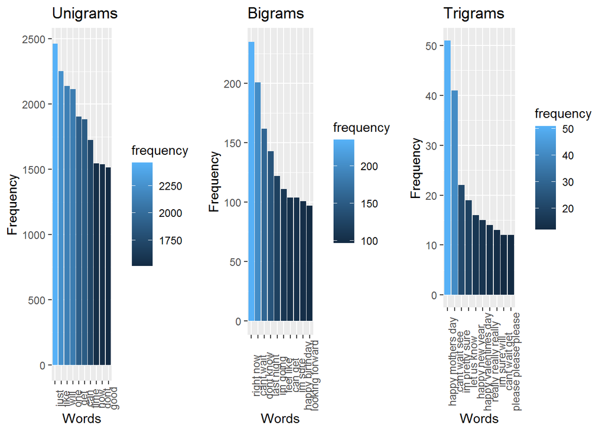

```r
library(ggplot2)
library(gridExtra)
# 1-grams plot
one_g<-ggplot(one_corpus_sort[1:10,],aes(x=reorder(Word,-frequency),y=frequency,fill=frequency))
one_g<-one_g+geom_bar(stat="identity")
one_g<-one_g+labs(title="Unigrams",x="Words",y="Frequency")
one_g<-one_g+theme(axis.text.x=element_text(angle=90))
# 2-grams plot
two_g<-ggplot(two_corpus_sort[1:10,],aes(x=reorder(Word,-frequency),y=frequency,fill=frequency))
two_g<-two_g+geom_bar(stat="identity")
two_g<-two_g+labs(title="Bigrams",x="Words",y="Frequency")
two_g<-two_g+theme(axis.text.x=element_text(angle=90))
# 3-grams plot
three_g<-ggplot(thr_corpus_sort[1:10,],aes(x=reorder(Word,-frequency),y=frequency,fill=frequency))
three_g<-three_g+geom_bar(stat="identity")
three_g<-three_g+labs(title="Trigrams",x="Words",y="Frequency")
three_g<-three_g+theme(axis.text.x=element_text(angle=90))
# Print the plots
grid.arrange(one_g, two_g, three_g,ncol=3)
```

## Conclusion and Next Steps

The next step will be to create a Shiny app and develop its user interface that will contain a text input box to accept text inputs. Then, a predictive algorithm will be built to take the user input and predict the next 1, 2 or 3 words based and these n-grams models we have built here. Finally, a pitch about the app will be prepared to allow prospect users to navigate its interface intuitively.